# I etap

Ewelina Karbowiak, Adrianna Wlazło

20 grudnia 2016

**Temat** Celem projektu jest zbadanie, jaki wpływ na końcowe wyniku testu ma przyjeta strategia rozwiązywania zadań przez uczniów.

# Dane

Dane pochodzą z projektu PISA 2015. Zawierały 8 557 694 wierszy opisujacych czas rozwiązywania danego zadania przez danego ucznia. Dane zawierają informacje o kraju i szkole, z której pochodził uczeń, numer rozwiązywanego zestawu, typ zadania (czytanie, matematyka) oraz numer części testu, w której to zadanie się znajdowało. Aby ułatwic prace nad danymi zamieniłyśmy czas podany w tysięcznych sekundy na minuty.

```r
dane <- onlyTimingsLong
head(dane)
```

```
##            Kraj  Szkola Student Zestaw    Czas Zadanie Pozycja Obszar
## 10737 Australia 3600001 3601769     31  195552 R219Q01       3      R
## 10742 Australia 3600001 3605983     85  143354 R219Q01       2      R
## 10747 Australia 3600001 3602143     36  206815 R219Q01       4      R
## 10759 Australia 3600002 3611016     37  117352 R219Q01       1      R
## 10787 Australia 3600003 3605314     36  174955 R219Q01       4      R
## 10794 Australia 3600003 3611875     41 1269775 R219Q01       2      R
```

# Wstępna analiza danych

W tabeli zostały zamieszczone dane z 58 krajów. Zadania znajdowały sie w 63 zestawach. Liczba zadan z matematyki i czytania jest różna. Ponadto jestst bardzo mało uczniów, którzy pisali jednocześnie zadania z matematyki i czytania. Liczba pozycji jest takze rożna i nie ma uczniow, którzy rozwiązywali więcej niż 2 pozycje. W danych spodziewałyśmy się znalezienia 4 pozycji, ponieważ tak skonstruowany jest test, jednak pojawia się też pozycja “-1”- być może są to dane testowe, nie jest to liczna grupa zadań (dla 4118 studentów). Jednak są uczniowie, dla których dysponujemy tylko danymi z tej pozycji. Postanowiłyśmy usunąć takie rekordy.

```r
length(levels(as.factor(dane$Zestaw)))
```

```
## [1] 63
```

```r
summary(dane$Obszar)
```

```
##       M       R
## 3892191 4665503
```

```r
summary(dane$Pozycja)
```

```
##      -1       1       2       3       4
##   30956 2173768 2061298 2167872 2123800
```

```r
table(dane$Obszar,dane$Pozycja)
```

```
##
##          -1       1       2       3       4
##   M   16371  986204  945464  979987  964165
##   R   14585 1187564 1115834 1187885 1159635
```

Poniżej przentujemy, jakich danych dostyczą kraje

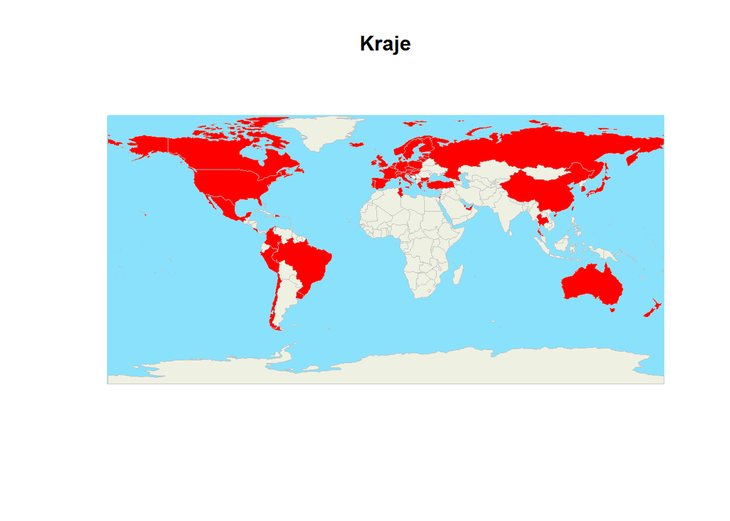

```r
summary(dane$Czas)
```

```
##     Min.  1st Qu.   Median     Mean  3rd Qu.     Max.
##   0.0024   0.5973   1.1170   1.4510   1.8980 734.0000
```

```
## Liczba pozycji na studenta przy pozycjach -1,1,2,3,4
```

```
##      1      2
##  77170 299510
```

```
## Liczba pozycji na studenta przy pozycjach 1,2,3,4
```

```
##      0      1      2
##   4118  73054 299508
```

jest 4118 uczniów, którzy mają uzupelnioną tylko pozycję -1.

# Czyszczenie danych

Z danych usunęłyśmy tych studentów, których suma czasu jaki poświęcili na zadania była większa niż 120 (bo tyle minut trwał test), oraz tych uczniów, którzy rozwiązali mniej niż 10 zadań. Usunęłyśmy również zadania z Pozycją -1.

```
## Rekordów do usunięcia z powodu za dużego czasu:  5566
##  Rekordów do usunięci z powodu błędnej pozycji:  30956
##  Rekordów do usunięcia z powodu małej ilości zadań:  2219
```

# Zadania matematyczne i z rozumienia tekstu w zależności od kraju

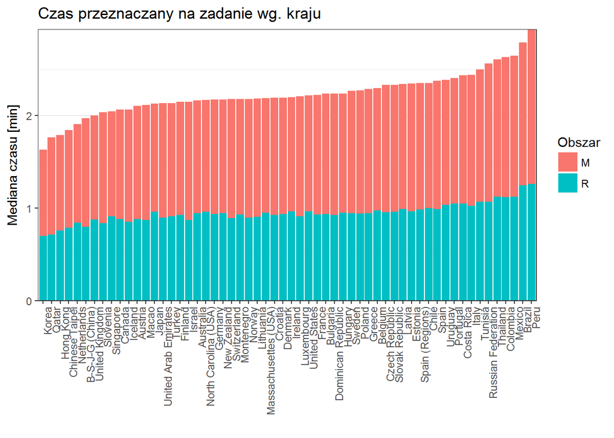

Z wykresu wyraźnie widzimy, że na zadania matematyczne uczniowie średnio poświęcali więcej czasu niż na zadania dotyczące czytania.

Na poniższej mapie mamy rozróżnione kraje względem średniego czasu rozwiązywania jednego zadania. W pliku napotykamy też bardzo duże wartości czasu, które znacznie odbiegają od realiów testu.

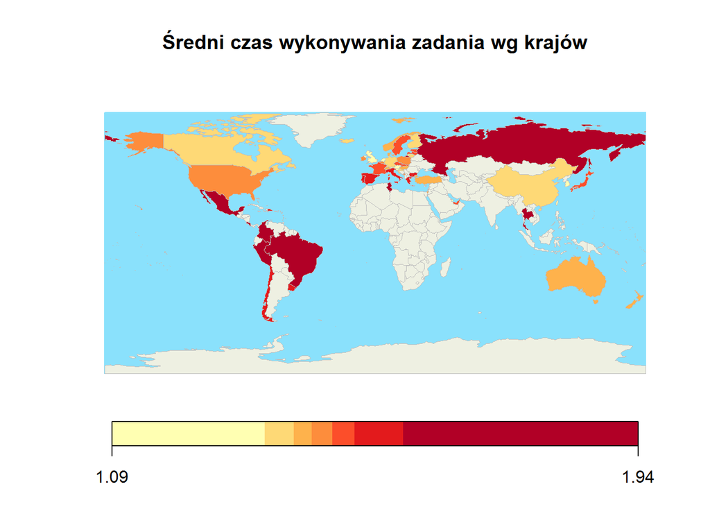

Postanowiłyśmy zbadać średni czas rozwiązywania zadania przez przeciętnego ucznia dla każdego kraju. Poniżej wykres otrzymanych wartości dla wszystkich krajów

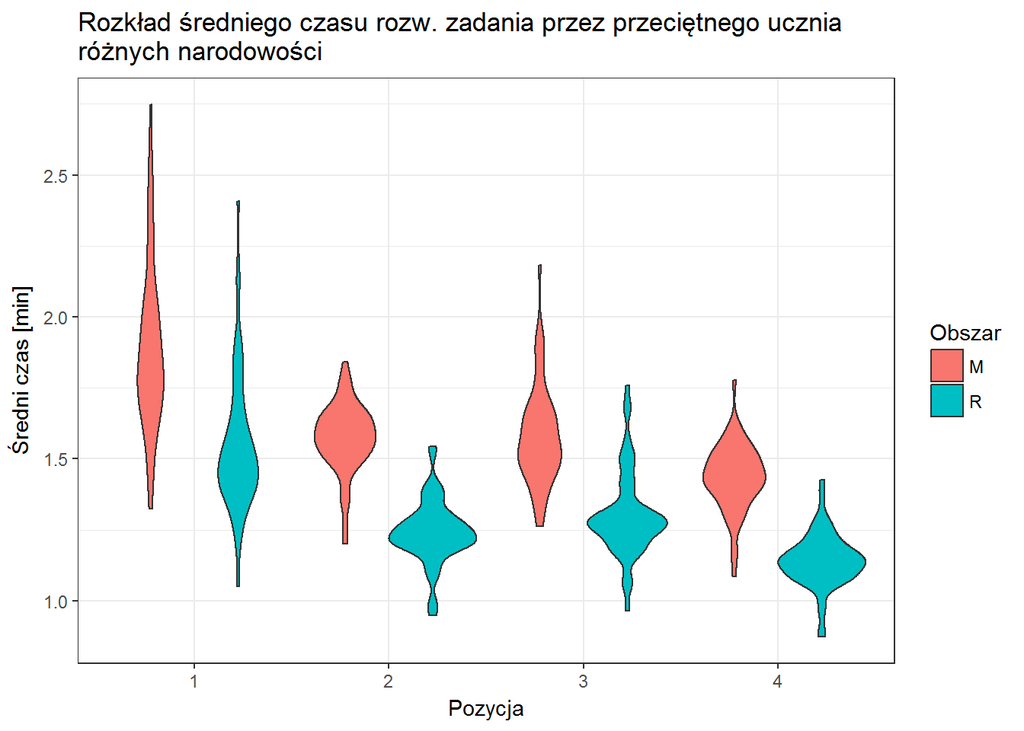